# Modgo simulation

# 1. Default *modgo* simulation

For illustration, we selected the Cleveland Clinic Heart Disease Data set from the University of California in Irvine (UCI) machine learning data repository (Dua and Graff 2017). Below, we are using eleven variables, five of which are continuous, four are dichotomous, and two categorical variables.

```r
data("Cleveland", package = "modgo")
```

```r
# Specifying dichotomous and ordinal categorical variables
binary_variables <- c("Sex","HighFastBloodSugar","CAD","ExInducedAngina")
categorical_variables <- c("Chestpaintype","RestingECG")
nrep <- 500
plot_variables <- c("Age", "STDepression", binary_variables[c(1,3)], categorical_variables)
```

In this section, we run *modgo* with his default settings. For *modgo* to produce results that mimic the original data set efficiently, user needs to specify dichotomous and ordinal categorical variables. Variables will be considered as continuous, otherwise. All *modgo* runs in this and the following sections will produce 500 data sets with the specification nrep = 500; the default is 100.

```r
test <- modgo(data = Cleveland,
              bin_variables = binary_variables,
              categ_variables = categorical_variables,
              nrep = nrep)
```

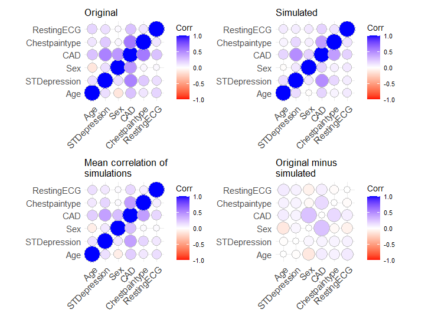

Figure 2: Correlation plots for a default *modgo* run.

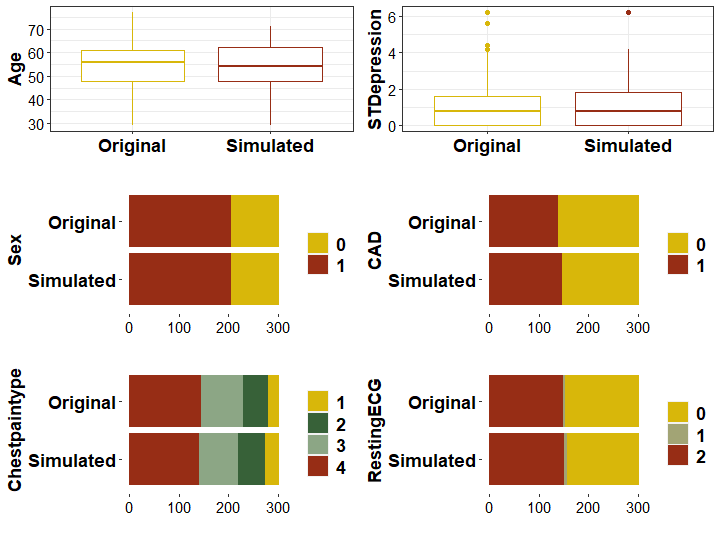

Figure 3: Distribution plots for a default *modgo* run.

# 2. Generalized lambda *modgo* simulation

One additional feature that *modgo* offers is simulating a data set using Generalized Lambdas Distribution().  
GLD method allow the user to simulate values that are not present in the original data set, since the default method uses only values from the original data.  
GLD method is based in the GLDEX package (Su 2007).

```r
test_GLD <- modgo(data = Cleveland,
                  bin_variables = binary_variables,
                  categ_variables = categorical_variables,
                  generalized_mode = TRUE,
                  nrep = nrep)
```

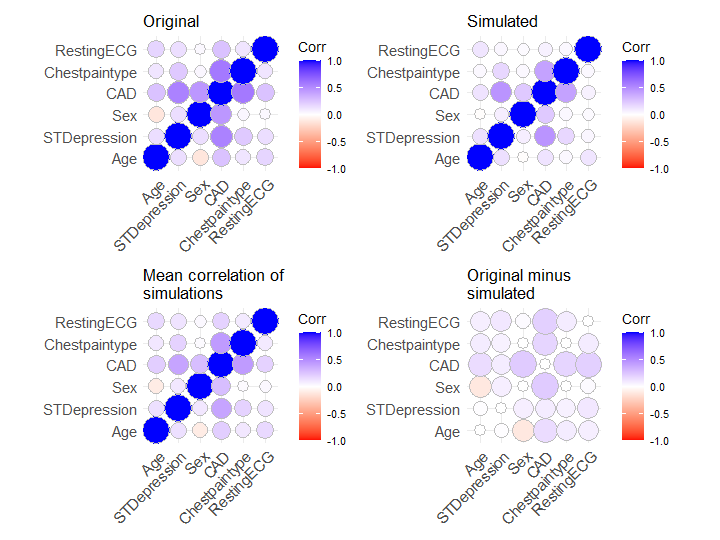

Figure 4: Correlation plots for Generalized Lambda Distribtion *modgo* run

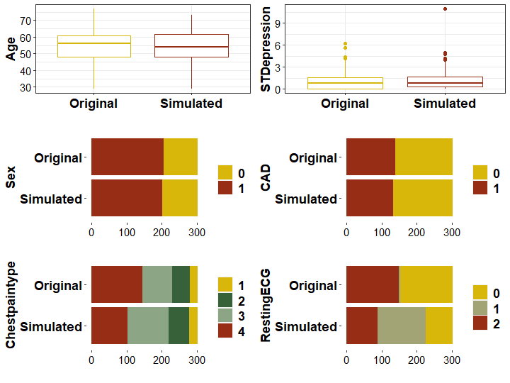

Figure 5: Distribution plot for Generalized Lambda Distribtion *modgo* run

GLDEX offers 3 basic models for calclualting the four Lambda’s for each distribution called rmfmkl(default model), rprs, star(reference), that can be also combined in for a bi-modal estimation.  
We offer the possibility to specify your desired model for each variable of the data set.  
Next, we demonstrate how to specify the desired GLD models.

```r
Variables <- c("Age","STDepression")
Model <- c("rprs", "star-rmfmkl")
model_matrix <- cbind(Variables,
                      Model)
```

```r
test_GLD_define_model <- modgo(data = Cleveland,
                  bin_variables = binary_variables,
                  categ_variables = categorical_variables,
                  generalized_mode = TRUE,
                  generalized_mode_model = model_matrix,
                  nrep = nrep)
```

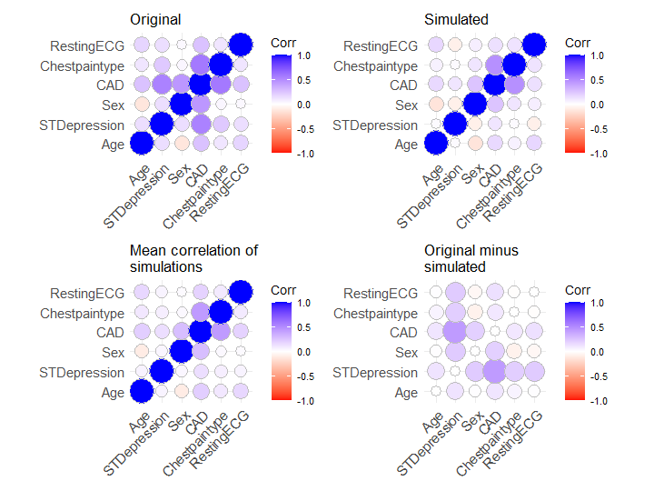

Figure 6: Correlation plots for Generalized Lambda Distribtion *modgo* run with specified GLD models

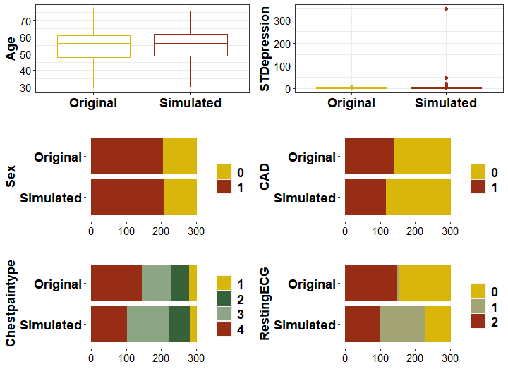

Figure 7: Distribution plots for Generalized Lambda Distribtion *modgo* run with specified GLD models

Looking at the distribution plots above we can see that in some variables like STDepression, GLD method can create values that are not present in the original data set and also are very extreme.

There is also the option to calculate Generalized Lambdas outside of *modgo* function and then use it as an argument to a later *modgo* run.

```r
gener_lambdas_matrix <- generalizedMatrix(data = Cleveland,
                                          generalized_mode_model = model_matrix,
                                          bin_variables = binary_variables)
test_GLD_define_model_set_lambdas <- modgo(data = Cleveland,
                  bin_variables = binary_variables,
                  categ_variables = categorical_variables,
                  generalized_mode = TRUE,
                  generalized_mode_lmbds = gener_lambdas_matrix,
                  nrep = nrep)
```

Finally, one interesting feature that it is offered to *modgo* with the help of GLD method is the ability to simulate data set without offering the original data. To run *modgo* without a data set this the user needs:  
1) Correlation matrix of the data set  
2) Generalized matrix of the data set  
3) Sample size of the simulated data set  
4) Variable names  
Below, we present an example of this case.

```r
# Necessary arguments
gener_lambdas_matrix <- generalizedMatrix(data = Cleveland,
                                          generalized_mode_model = model_matrix,
                                          bin_variables = binary_variables)
sigma <- cor(Cleveland)
variables_names <- colnames(sigma)
sample_size <- 100

test_GLD_no_data_set <- modgo(data = NULL,
                              variables = variables_names,
                              bin_variables = binary_variables,
                              categ_variables = categorical_variables,
                              sigma = sigma,
                              generalized_mode = TRUE,
                              generalized_mode_lmbds = gener_lambdas_matrix,
                              n_samples = sample_size,
                              nrep = nrep)
```

```
## Data set is not provided
```

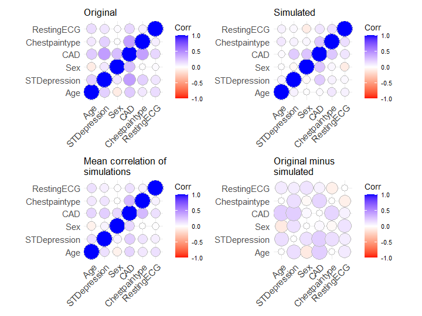

Figure 8: Correlation plots for Generalized Lambda Distribtion *modgo* run without providing a data set

# 3. Survival example

For illustration of survival variable simulation, we selected the cancer data set provided by *survival* package (Therneau 2023). Cancer data set consists of 167 samples and 10 variables. To set up modgo_survival(), the user needs to specify along with the other arguments of *modgo* a status and a time variable.

```r
# cancer prepare
data("cancer", package = "survival")

cancer <- na.omit(cancer)
cancer$sex <- cancer$sex - 1
cancer$status <- cancer$status - 1

time_var_cancer <- "time"
status_var_cancer <- "status"
bin_var_cancer <- c("status", "sex")
cat_var_list_cancer <- c("ph.ecog")

plot_variables_surv <- colnames(cancer)[1:6]
```

modgo_survival function splits the data set in two data sets according to the status variable and then it simulates each separately thought Generalized Lambdas Distribution method. User can specify for each data set which GLDEX model should be used(default = “rprs”).

```r
# Survival run
test_surv <- modgo_survival(data = cancer,
               surv_method = 1,
               bin_variables = bin_var_cancer,
               categ_variables = cat_var_list_cancer,
               event_variable = status_var_cancer,
               time_variable = time_var_cancer,
               generalized_mode_model_no_event = "rmfmkl",
               generalized_mode_model_event = "rprs")
```

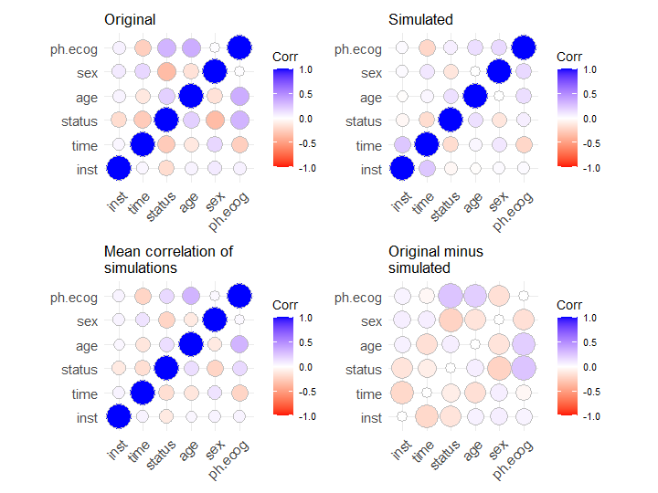

Figure 9: Correlation plots for modgo_survival run

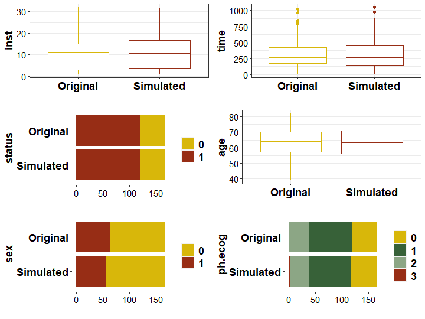

Figure 10: Distribution plots for modgo_survival run

In the upcoming plot, the surv_fit() curves from the *survival* package for both original and simulate data are depicted.

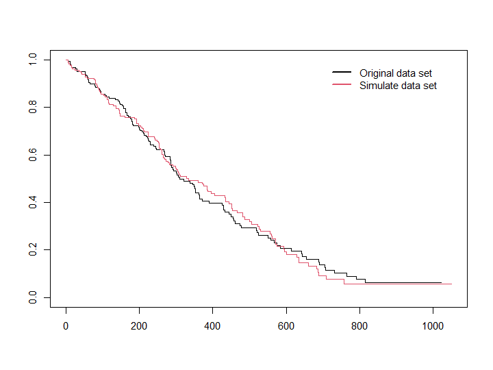

Figure 10: Survival fit curves plot for modgo_survival run

```r
data_set_info <- c(rep(0, dim(test_surv$original_data)[1]),
                   rep(1, dim(test_surv$simulated_data[[1]])[1]))
combine_data_set <- rbind(test_surv$original_data,
                          test_surv$simulated_data[[1]])
combine_data_set <- cbind(combine_data_set,
                          data_set_info)
fit <- survfit(Surv(time, status) ~ data_set_info,
               data=combine_data_set)
plot(fit,
     col=1:2)
legend(700, 1,
       c("Original data set", "Simulate data set"),
       lty=c(1,1),
       col=c(1,2),
       bty='n',
       lwd=2)
```

# References

Dua, Dheeru, and Casey Graff. 2017. “UCI Machine Learning Repository.” University of California, Irvine, School of Information; Computer Sciences. http://archive.ics.uci.edu/ml.

Su, Steve. 2007. “Fitting Single and Mixture of Generalized Lambda Distributions to Data via Discretized and Maximum Likelihood Methods: GLDEX in r.” *Journal of Statistical Software* 21 (9): 1–17. https://doi.org/10.18637/jss.v021.i09.

Therneau, Terry M. 2023. *A Package for Survival Analysis in r*. https://CRAN.R-project.org/package=survival.